# assignment4

Anier Velasco Sotomayor

2023-03-01

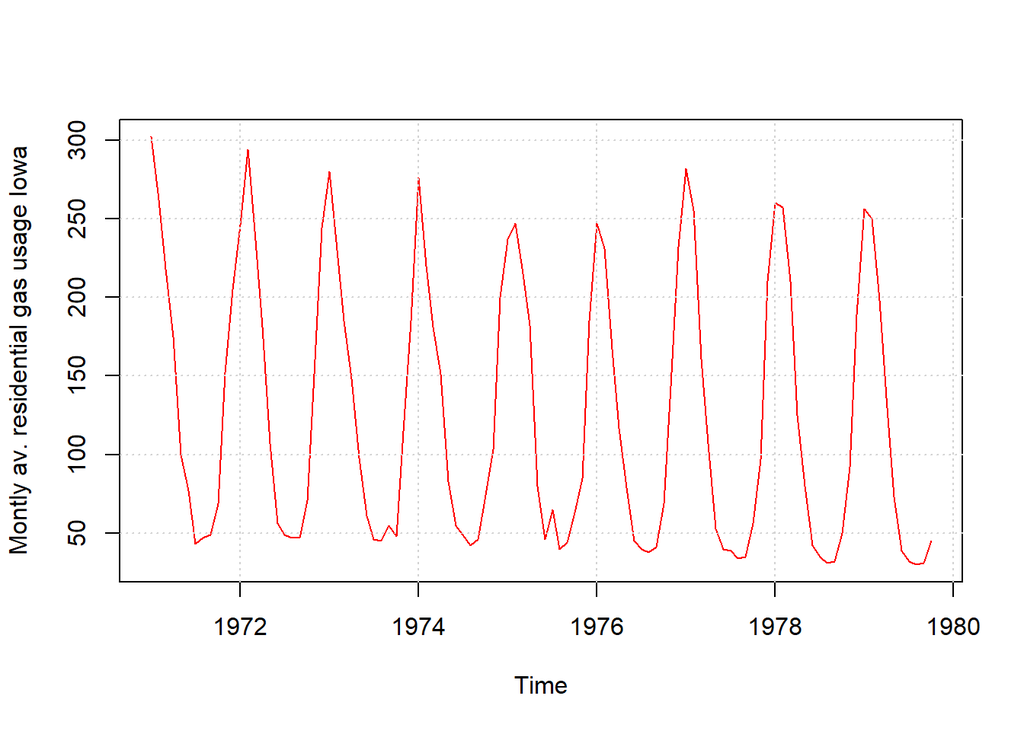

The behavior of series does not differ significantly over period of time, so we will work with entire dataset.

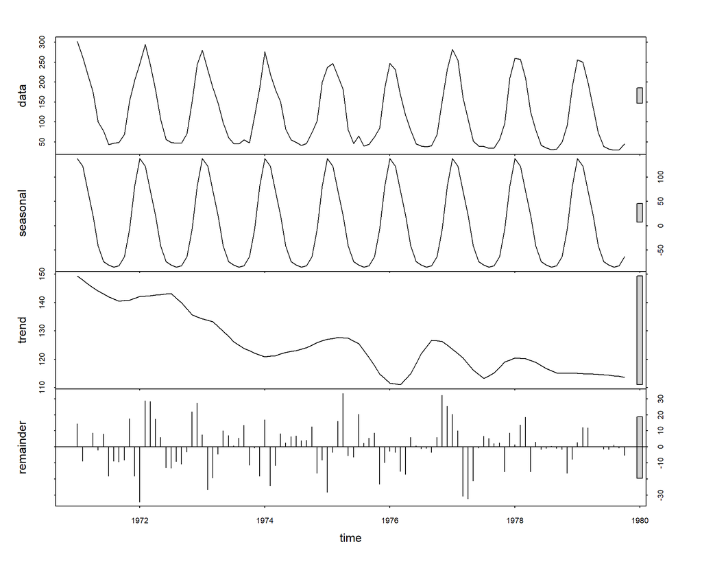

We need to transform the data, since we can observe different variance over time Box-Cox transformation with optimal $\lambda$:

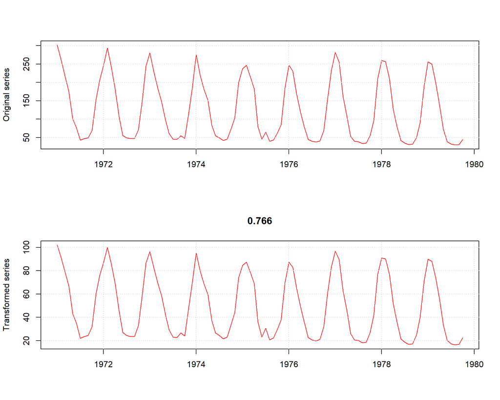

Now let’s work on models

## ETS MODEL

```
## ETS(A,N,A)
##
## Call:
##  ets(y = tSeries, lambda = LambdaOpt, biasadj = T)
##
##   Box-Cox transformation: lambda= 0.7656
##
##   Smoothing parameters:
##     alpha = 0.4209
##     gamma = 1e-04
##
##   Initial states:
##     l = 55.5684
##     s = 26.6466 -0.4751 -20.3379 -27.5822 -28.6902 -26.9913
##            -23.6299 -11.9788 8.5052 23.663 38.4309 42.4397
##
##   sigma:  5.266
##
##      AIC     AICc      BIC
## 861.4986 866.8320 901.4502
```

Now we observe residuals:

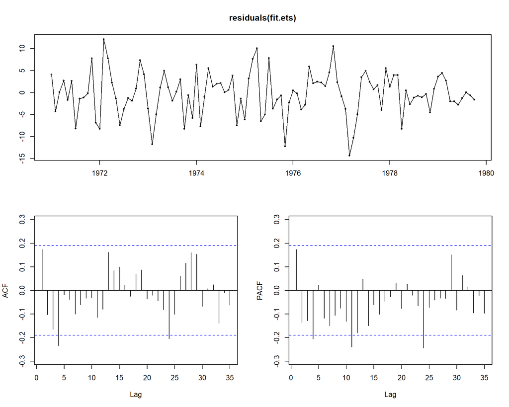

Residuals do not look like a white noise. Also we can see that there is still some autocorrelated residuals left. So it might be the case, that ETS model did not capture all of the structure of data. Ljung-Box test p-values for them:

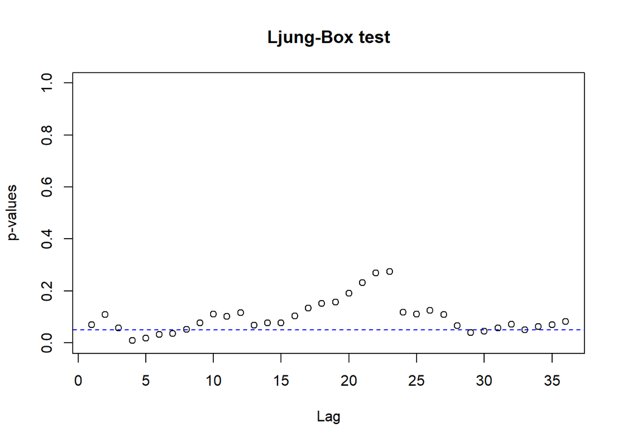

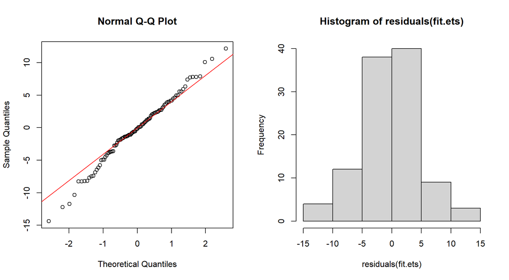

| Hypothesis | Test | Result | P-value |
| --- | --- | --- | --- |
| Normality | Shapiro-Wilk | not rejected | 0.6316342 |
| Unbiasedness | Wilcoxon | not rejected | 0.7670181 |
| Stationarity | KPSS | not rejected | 0.1 |

OK, residuals are normal, unbiased and stationary. This is good.

Fitting the selected model to the first $T-D$ points of the series to check the accuracy of the forecast on the last $D$ points:

```
##                     ME     RMSE       MAE       MPE      MAPE      MASE
## Training set -1.201991 16.45109 12.298328 -2.599185 11.731746 0.6873813
## Test set      7.590201 12.09434  8.143963  4.494376  5.724959 0.4551845
##                   ACF1 Theil's U
## Training set 0.1592562        NA
## Test set     0.6532208 0.2171934
```

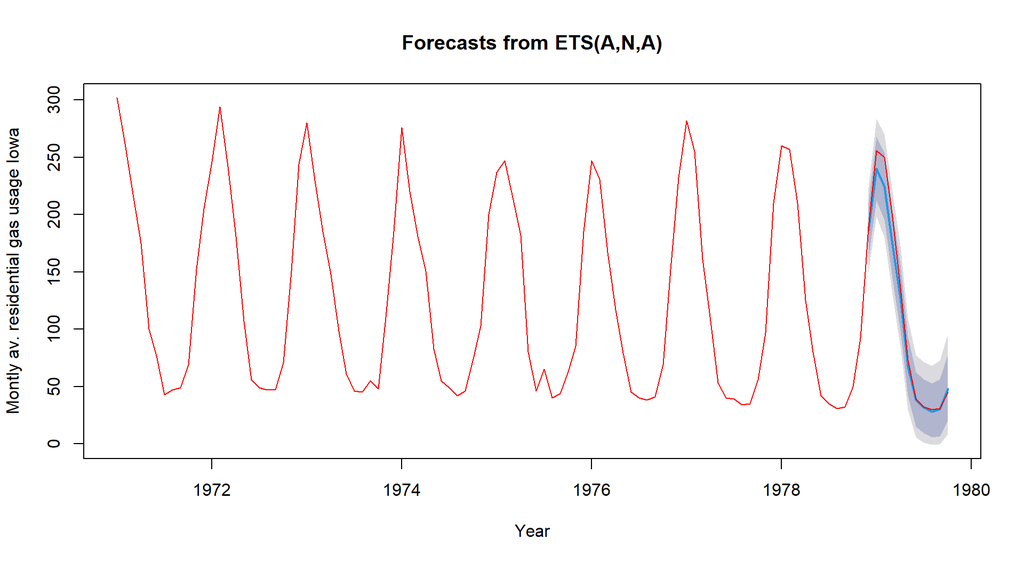

## Auto-ARIMA

```
## Series: tSeries
## ARIMA(1,0,0)(2,1,1)[12] with drift
## Box Cox transformation: lambda= 0.7656026
##
## Coefficients:
##          ar1     sar1     sar2     sma1    drift
##       0.3976  -0.0972  -0.1643  -0.7599  -0.1019
## s.e.  0.0965   0.2492   0.1965   0.3674   0.0245
##
## sigma^2 = 25.32:  log likelihood = -290.13
## AIC=592.25   AICc=593.22   BIC=607.51
```

ARIMA(1,0,0)(2,1,1)$_{12}$ is selected. Here are the residuals:

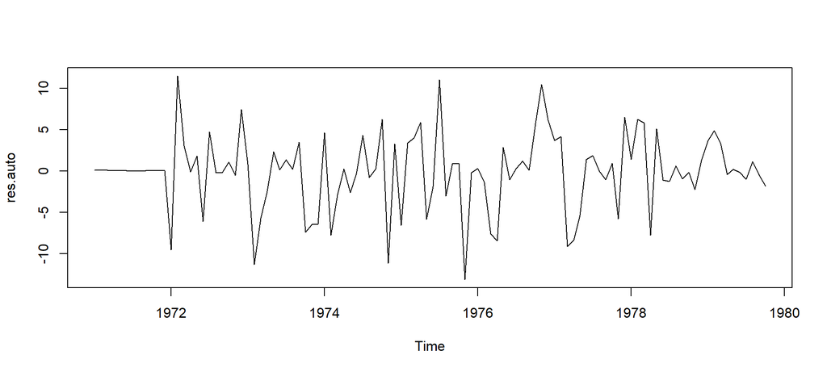

At the beginning residuals are not defined properly; let’s cut the first 12 before proceeding with residual analysis.

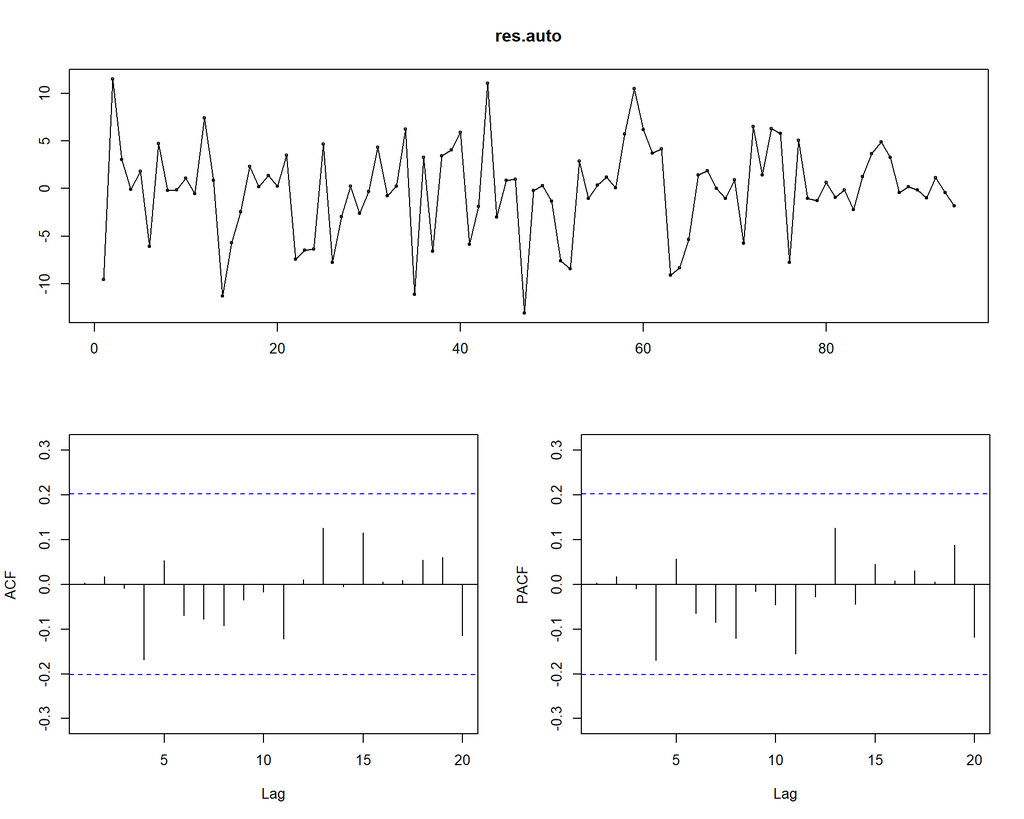

Here results are better for residuals. No high autocorrelation and partial autocorrelation

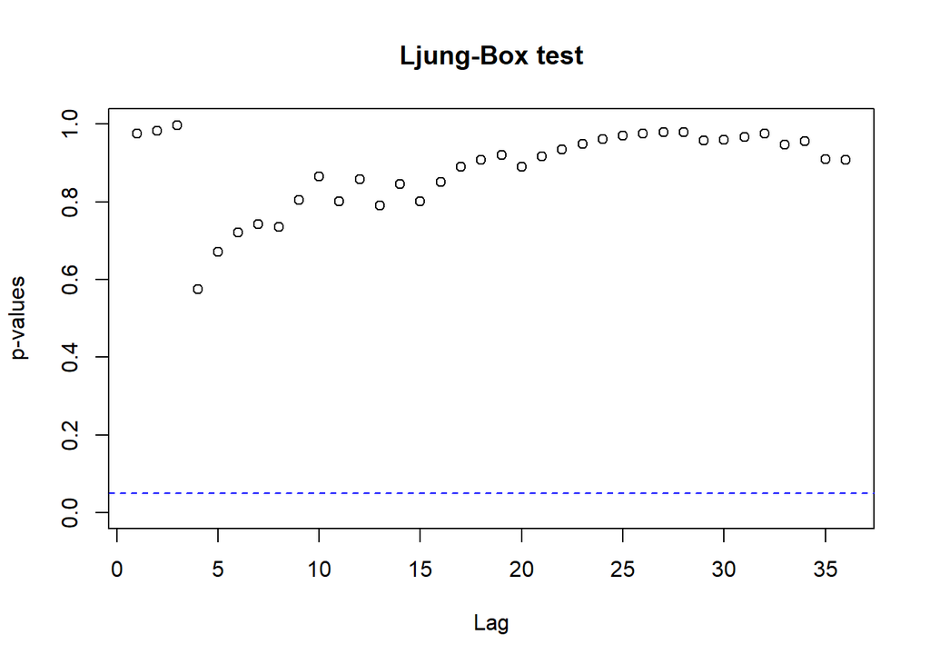

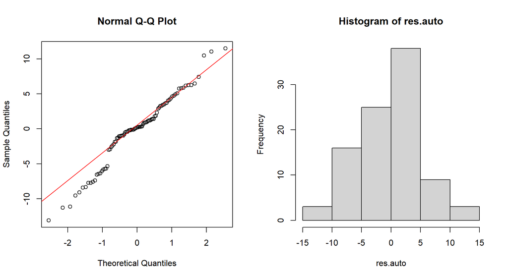

| Hypothesis | Test | Result | P-value |
| --- | --- | --- | --- |
| Normality | Shapiro-Wilk | rejected | 0.0270445 |
| Unbiasedness | Wilcoxon | not rejected | 0.8504481 |
| Stationarity | KPSS | not rejected | 0.1 |

Fitting the selected model to the first $T-D$ points of the series to check the accuracy of the forecast on the last $D$ points: ARIMA(1,0,0)(2,1,1)[12] with drift

```
##                      ME     RMSE       MAE       MPE     MAPE      MASE
## Training set -0.6322109 15.67118 10.767396 -1.246489 9.559667 0.6018140
## Test set      7.1827793 12.11019  8.716487  3.129522 6.990782 0.4871841
##                    ACF1 Theil's U
## Training set 0.02111029        NA
## Test set     0.67732489 0.2753445
```

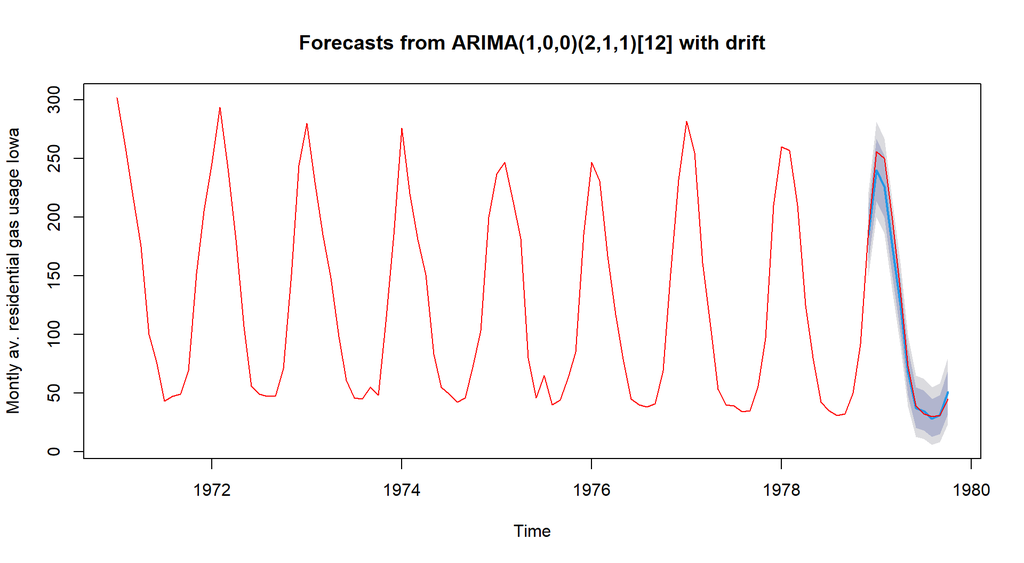

### Manual model tuning The series are seasonal, so we want to perform seasonal differencing.

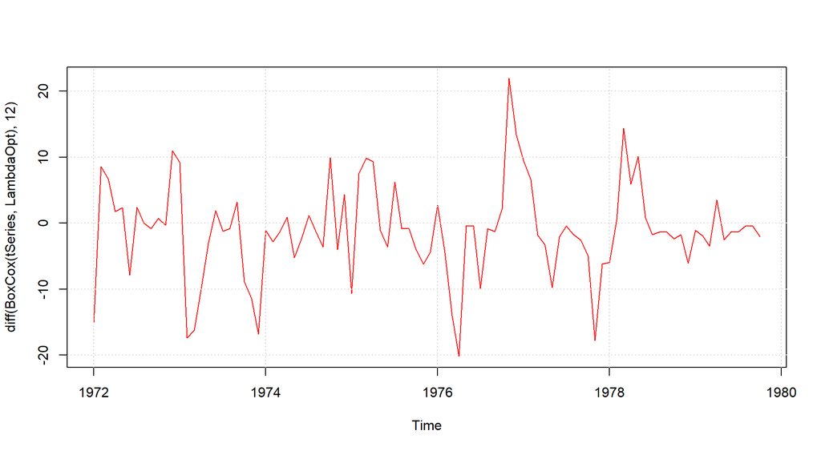

Let’s see if regular differencing makes it more better.

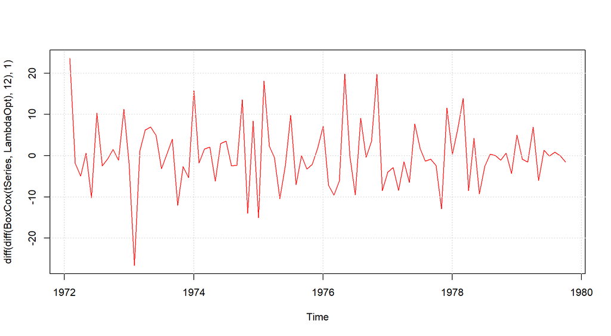

The hypothesis of stationarity is not rejected (p>0.1, KPSS test).

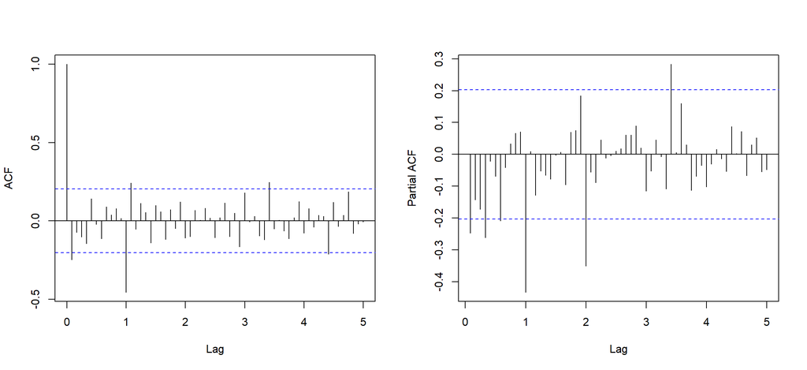

Autocorrelation is significantly different from 0 for lags 1, 12, 13, 41, 53 Since 12 is maximal significant seasonal lag, we could use $Q = 12/12 = 1$ as an initial approximation. Maximal significant lag before 12 is 1, hence the starting value $q=1$.

Partial autocorrelation is significantly different from 0 for lags 1, 4, 7, 12, 24, 41 Following the same logic as above, we select initial values $P=2$, $p=7$.

```
## Series: tSeries
## ARIMA(2,1,0)(2,1,0)[12]
## Box Cox transformation: lambda= 0.7656026
##
## Coefficients:
##           ar1      ar2     sar1     sar2
##       -0.3085  -0.2334  -0.6749  -0.5121
## s.e.   0.1031   0.1010   0.0903   0.0954
##
## sigma^2 = 34:  log likelihood = -298.97
## AIC=607.93   AICc=608.62   BIC=620.59
```

The lowest AICc has ARIMA(2,1,0)(2,1,0)$_{12}$. Does it have good residuals?

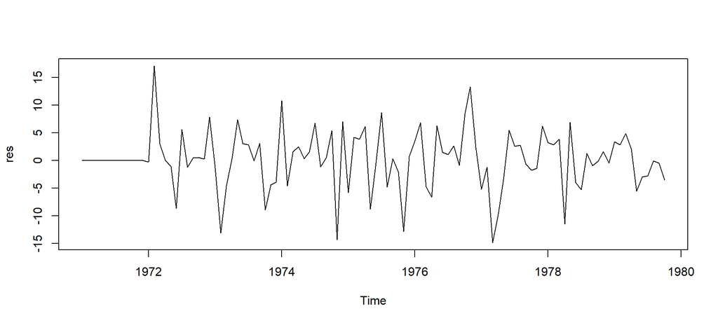

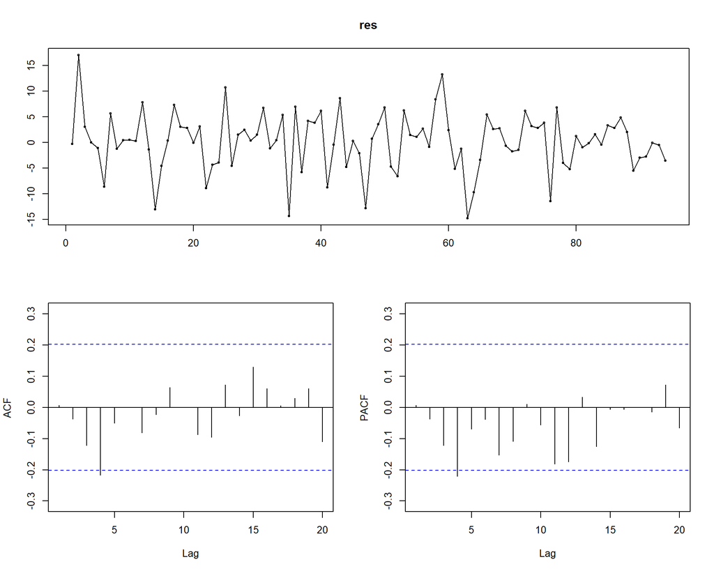

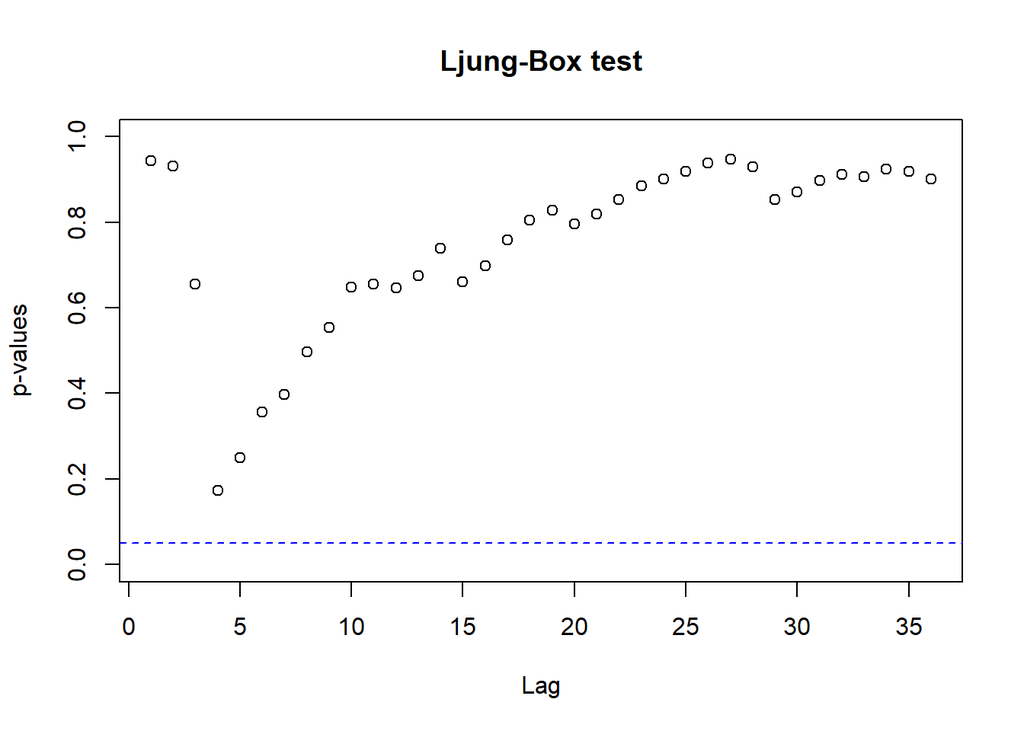

Q-Q plot and histogram of the residuals:

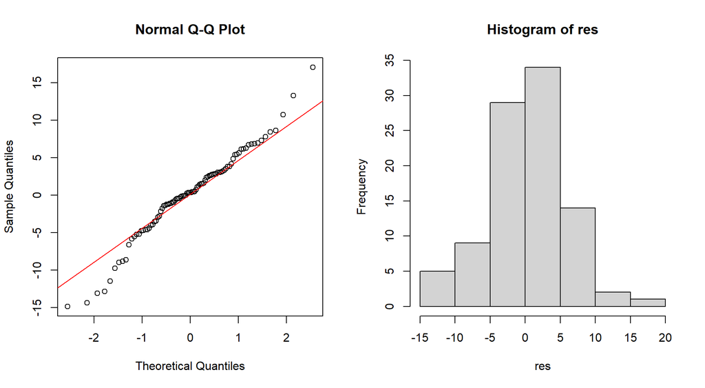

| Hypothesis | Test | Result | P-value |
| --- | --- | --- | --- |
| Normality | Shapiro-Wilk | not rejected | 0.0765027 |
| Unbiasedness | Wilcoxon | not rejected | 0.4690538 |
| Stationarity | KPSS | not rejected | 0.1 |

```
##                     ME     RMSE      MAE        MPE      MAPE      MASE
## Training set 0.1442807 17.70332 11.92910 -0.8256253 11.641143 0.6667442
## Test set     7.6779155 14.59320 10.07901  2.9723924  8.419502 0.5633386
##                   ACF1 Theil's U
## Training set 0.0181942        NA
## Test set     0.6268890 0.3836289
```

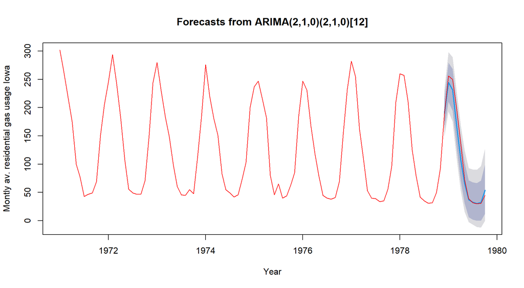

## Final model selection

Comparing the residuals of two ARIMAs:

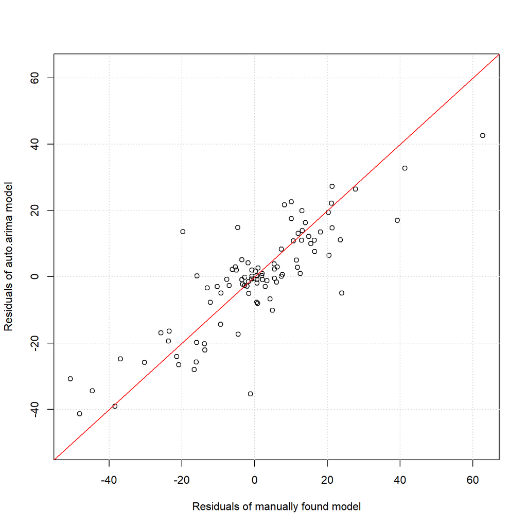

Residuals are different from auto ARIMA and manually tuned ARIMA.

Auto ARIMA vs Manual

```
##
##  Diebold-Mariano Test
##
## data:  resres.auto
## DM = 1.8906, Forecast horizon = 1, Loss function power = 2, p-value =
## 0.0618
## alternative hypothesis: two.sided
```

We cannot reject that there is no significant difference in forecasting error between auto ARIMA and manual ARIMA. Based on AICc score and losses on test set and Theil’s U it should be safe to prefer auto ARIMA over manual ARIMA.

Now let’s compare it to ets model Comparing the residuals of the best ARIMA and the best ETS models:

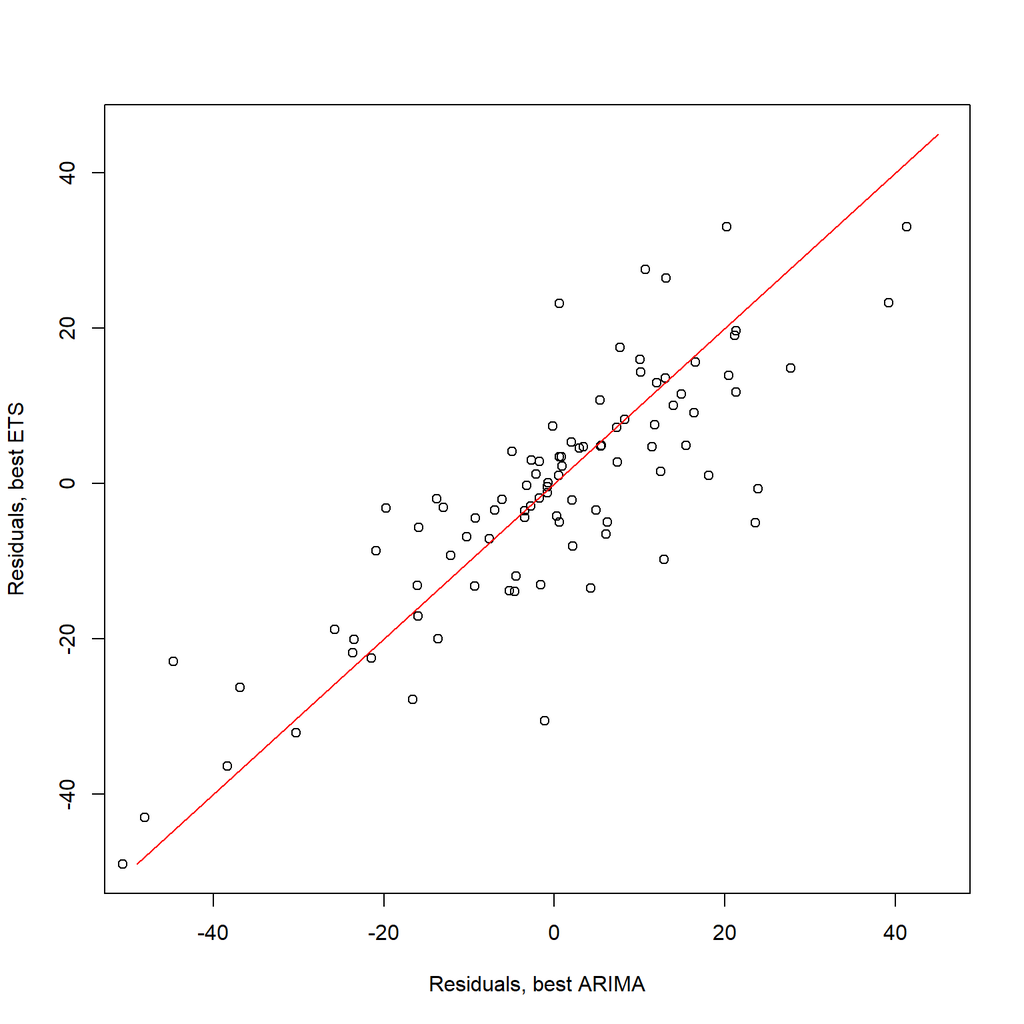

Their residuals are also different.

```
##
##  Diebold-Mariano Test
##
## data:  res.autores.ets
## DM = -0.28918, Forecast horizon = 1, Loss function power = 2, p-value =
## 0.7731
## alternative hypothesis: two.sided
```

```
##
##  Diebold-Mariano Test
##
## data:  res.autores.ets
## DM = -0.28918, Forecast horizon = 1, Loss function power = 2, p-value =
## 0.6135
## alternative hypothesis: greater
```

For this hard decision, I decide to use auto ARIMA model based on AICc.

## Forecast

```
##          Point Forecast     Lo 80     Hi 80      Lo 95     Hi 95
## Nov 1979       99.89861  81.04428 119.08818  71.579496 129.70257
## Dec 1979      187.60981 164.00578 211.49046 151.927496 224.51639
## Jan 1980      243.68732 218.32606 269.29359 205.267303 283.19156
## Feb 1980      227.33019 202.34516 252.57036 189.501441 266.28801
## Mar 1980      171.10950 147.76309 194.75314 135.853831 207.68079
## Apr 1980      122.91869 101.36342 144.82913  90.497057 156.91317
## May 1980       63.52264  45.19895  82.35593  36.311807  92.99534
## Jun 1980       35.50005  19.72496  51.98639  12.583795  61.59448
## Jul 1980       31.53241  16.25232  47.57644   9.488468  56.99985
## Aug 1980       26.49199  11.93050  41.90507   5.753326  51.07163
## Sep 1980       28.96047  14.03247  44.69354   7.549332  53.98936
```

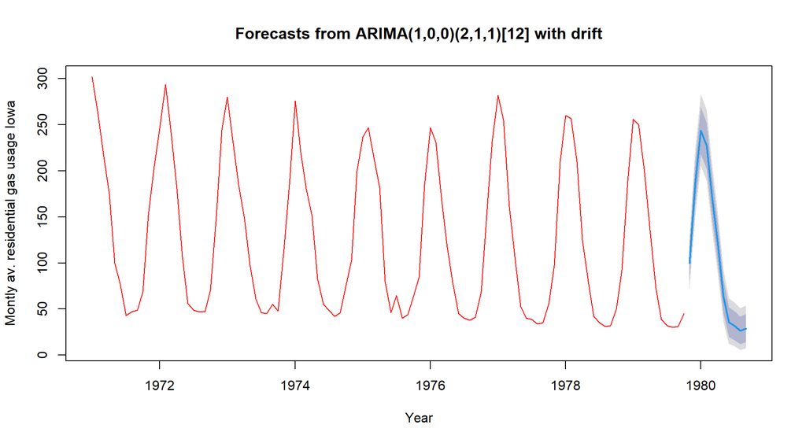